# 情報科学3

ロジスティック回帰 (1)

矢内 勇生

2021-10-24（改訂: 2021-10-25）

## 準備

必要なパッケージを読み込む。

```r
pacman::p_load(tidyverse,
               broom)
```

次に、ggplot2のテーマとフォントの設定を行う。自分好みの設定がある場合は自由に変えてよい。

```r
if (.Platform$OS.type == "windows") {
  if (require(fontregisterer)) {
    my_font <- "Yu Gothic"
  } else {
    my_font <- "Japan1"
  }
} else if (capabilities("aqua")) {
  my_font <- "HiraginoSans-W3"
} else {
  my_font <- "IPAexGothic"
}

theme_set(theme_gray(base_size = 9,
                     base_family = my_font))
```

説明のために『Rによる計量政治学』（浅野正彦, 矢内勇生. 2018）で使用されているデータ（hr-data.csv） を使う。 まず、このデータをダウンロードする。

```r
download.file(
  url = "https://raw.githubusercontent.com/yukiyanai/quant-methods-R/master/data_fixed/hr-data.csv",
  dest = "data/hr-data.csv"
)
```

ダウンロードしたデータを読み込む。

```r
HR <- read_csv("data/hr-data.csv")
```

小選挙区での当落を表すダミー変数（これを二値の応答変数として扱う）を作る。

```r
HR <- HR %>%
  mutate(wlsmd = ifelse(wl == "当選", 1, 0))
```

2009年の結果だけ抜き出し、HR09として保存する。

```r
HR09 <- HR %>%
  filter(year == 2009)
```

expが欠測の個体が1つあるので、（とりあえず）除外しておく。

```r
HR09 <- na.omit(HR09)
```

## 説明変数が1つのロジスティック回帰

例として、2009年の衆院選データを用い、選挙費用（`expm`, 単位100万円）で衆院選小選挙区での当落 (`wlsmd`) を説明するモデルを考える。このモデルを式で表すと、
$$\mathrm{Pr}(\text{当選}) = \mathrm{logit}^{-1}(\alpha + \beta \text{選挙費用})$$
となる。

まず、2つの変数の関係を図示してみよう。

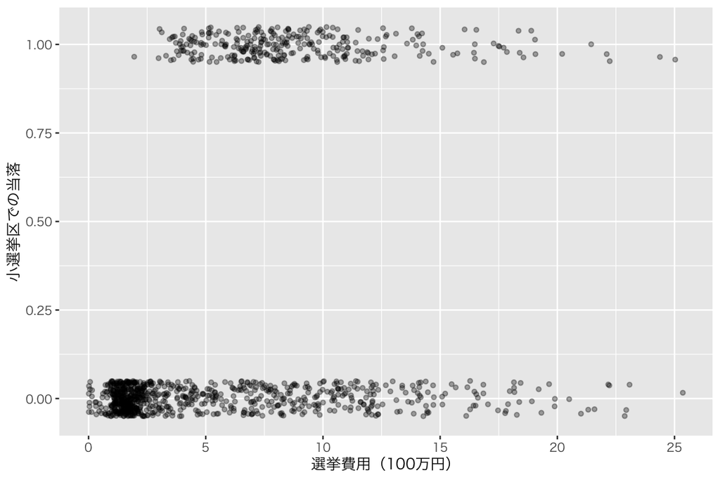

```r
p <- ggplot(HR09, aes(x = expm, y = wlsmd)) +
  geom_jitter(size = 1,
              alpha = 1/3,
              width = 0,
              height = 0.05) +
  labs(x = "選挙費用（100万円）",
       y = "小選挙区での当落")
plot(p)
```

これに（無理やり）通常の回帰直線を当てはめると、

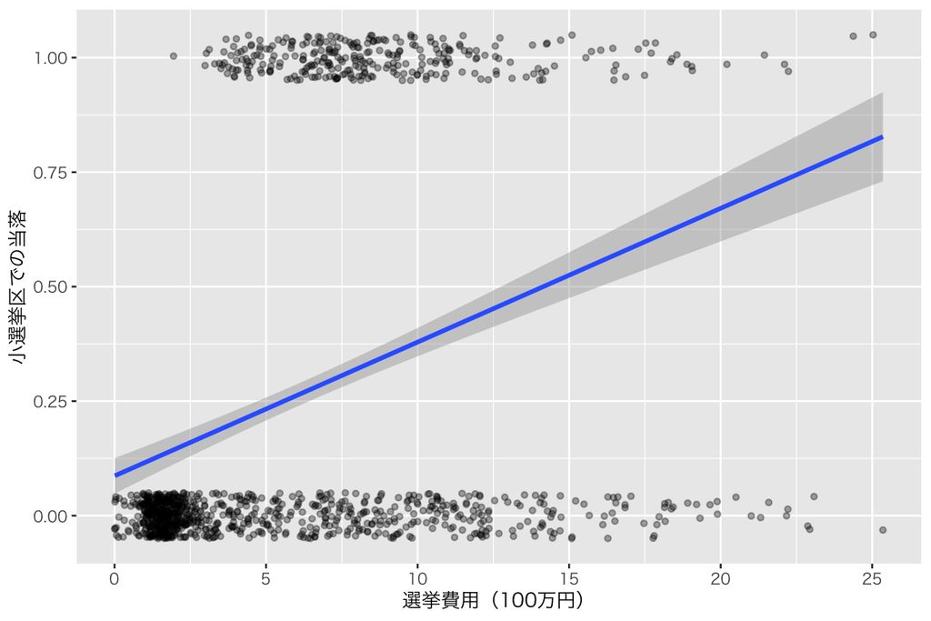

```r
plot(p + geom_smooth(method = "lm"))
```

となる。

Rでロジスティック回帰分析を行うには`glm()` を使う。 この関数は、一般化線形モデル (Generalized Linear Models: GLM) を当てはめるための関数で、ロジスティック回帰以外でも頻繁に使う関数である。 この関数をロジスティック回帰分析に使うには、引数`family = binomial(link = "logit")` を指定する。

```r
fit1 <- glm(wlsmd ~ expm,
            data = HR09,
            family = binomial(link = "logit"))
```

推定結果を確認する。

```r
tidy(fit1, conf.int = TRUE)
```

```
## # A tibble: 2 × 7
##   term        estimate std.error statistic  p.value conf.low conf.high
##   <chr>          <dbl>     <dbl>     <dbl>    <dbl>    <dbl>     <dbl>
## 1 (Intercept)   -2.01     0.126      -16.0 2.82e-57   -2.26     -1.77
## 2 expm           0.146    0.0142      10.3 1.14e-24    0.118     0.174
```

これで、推定はできた。

**問題：推定値はどう解釈する？**

次に、成功確率の予測値を求めよう。 予測値を求めるには、OLSのときと同様、`predict()` を使えばよい。 ただし、`predict()`のデフォルトでは、線形予測子の測定単位で予測値を返す。 ロジスティック回帰の線形予測子$X\beta$ は対数オッズスケール $(-\infty, \infty)$ なので、 `predict(fit1)`とすると、成功確率が返ってこない（各自で確かめてみること）。 私たちが欲しいのは確率なので、`type = "response"` を指定し、応答変数の測定単位で値を得る（ここで、応答 [response] と考えられているのは、当落そのものではなく、当選確率であることに注意）。

```r
HR09 <- HR09 %>%
  mutate(pred = predict(fit1, type = "response"))
```

これを図示してみよう。

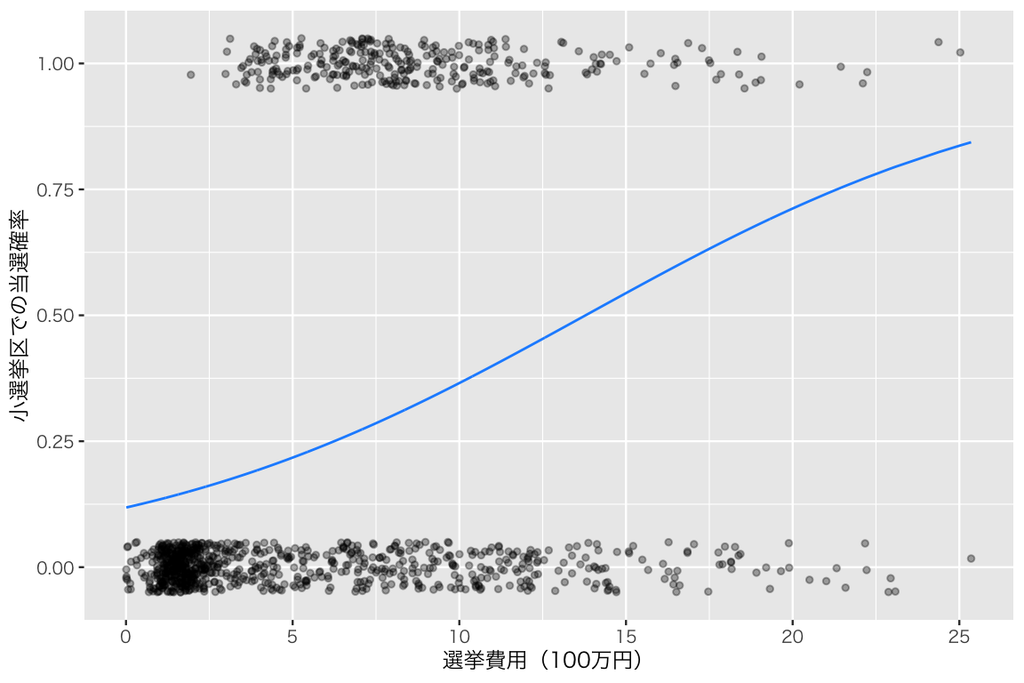

```r
p_pred <- p +
  geom_line(data = HR09,
            aes(x = expm, y = pred),
            color = "dodgerblue") +
  labs(x = "選挙費用（100万円）",
       y = "小選挙区での当選確率")
plot(p_pred)
```

あるいは、ggplot2の機能を利用して、次のようにすることもできる。

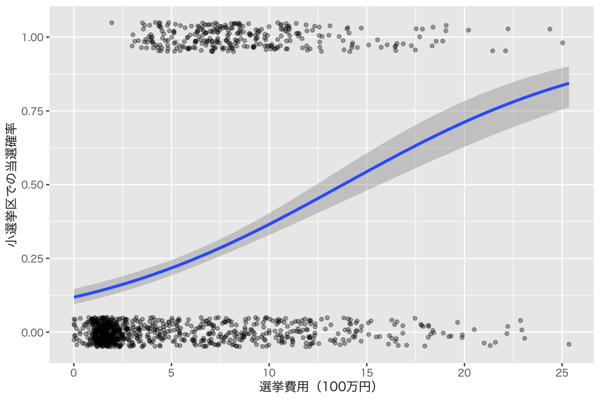

```r
p3 <- ggplot(HR09, aes(x = expm, y = wlsmd)) +
  geom_jitter(size = 1,
              alpha = 1/3,
              width = 0,
              height = 0.05) +
  geom_smooth(method = "glm",
              method.args = list(family = binomial(link = "logit"))) +
  labs(x = "選挙費用（100万円）",
       y = "小選挙区での当選確率")
print(p3)
```

## 説明変数が2つ以上のロジスティック回帰

説明変数が増えても、基本的な分析法は変わらない。 先ほどまでのモデルに、過去の当選回数 (`previous`) という説明変数を加えてみよう。

ロジスティック回帰を当てはめると、次のような結果が得られる。

```r
fit2 <- glm(wlsmd ~ expm + previous,
            data = HR09,
            family = binomial(link = "logit"))
tidy(fit2, conf.int = TRUE)
```

```
## # A tibble: 3 × 7
##   term        estimate std.error statistic  p.value conf.low conf.high
##   <chr>          <dbl>     <dbl>     <dbl>    <dbl>    <dbl>     <dbl>
## 1 (Intercept)  -2.03      0.132     -15.4  2.31e-53  -2.30     -1.78
## 2 expm          0.0500    0.0181      2.77 5.62e- 3   0.0144    0.0853
## 3 previous      0.324     0.0370      8.75 2.06e-18   0.253     0.399
```

**問題：この推定結果をどう解釈する？**

選挙費用が平均値のときの当選確率の予測値は次のように求める。

```r
HR09 <- HR09 %>%
  mutate(pred2 = predict(fit2,
                         type = "response",
                         list(previous = previous,
                              expm = rep(mean(expm), n()))))
```

これを図示しよう。

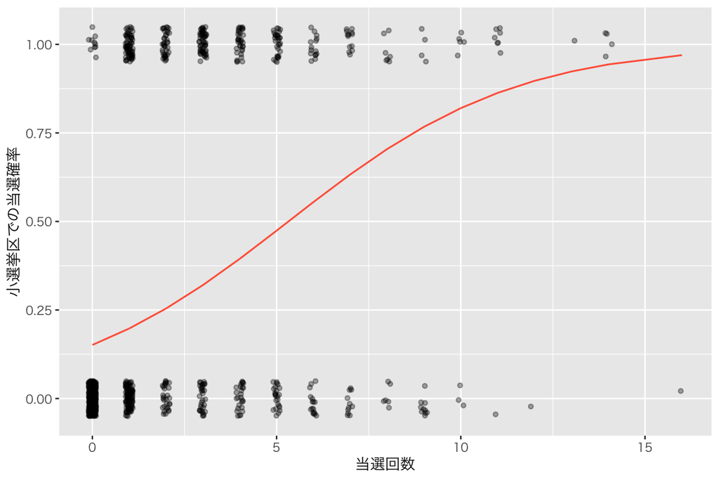

```r
p_pred2 <- ggplot(HR09, aes(x = previous)) +
  geom_jitter(aes(y = wlsmd),
              size = 1,
              alpha = 1/3,
              width = 0.1,
              height = 0.05) +
  geom_line(aes(y = pred2), color = "tomato") +
  labs(x = "当選回数",
       y = "小選挙区での当選確率")
print(p_pred2)
```

これに信頼区間を加えよう。そのために、まず各予測値の標準誤差を求める。

```r
HR09 <- HR09 %>%
  mutate(se2 = predict(fit2, type = "response",
                       list(previous = previous,
                            expm = rep(mean(expm), n())),
                       se.fit = TRUE)$se.fit)
```

```r
HR09 <- HR09 %>%
  mutate(fit2_lb = pred2 - 2 * se2,
         fit2_ub = pred2 + 2 * se2)
```

求めた区間を図示しよう。

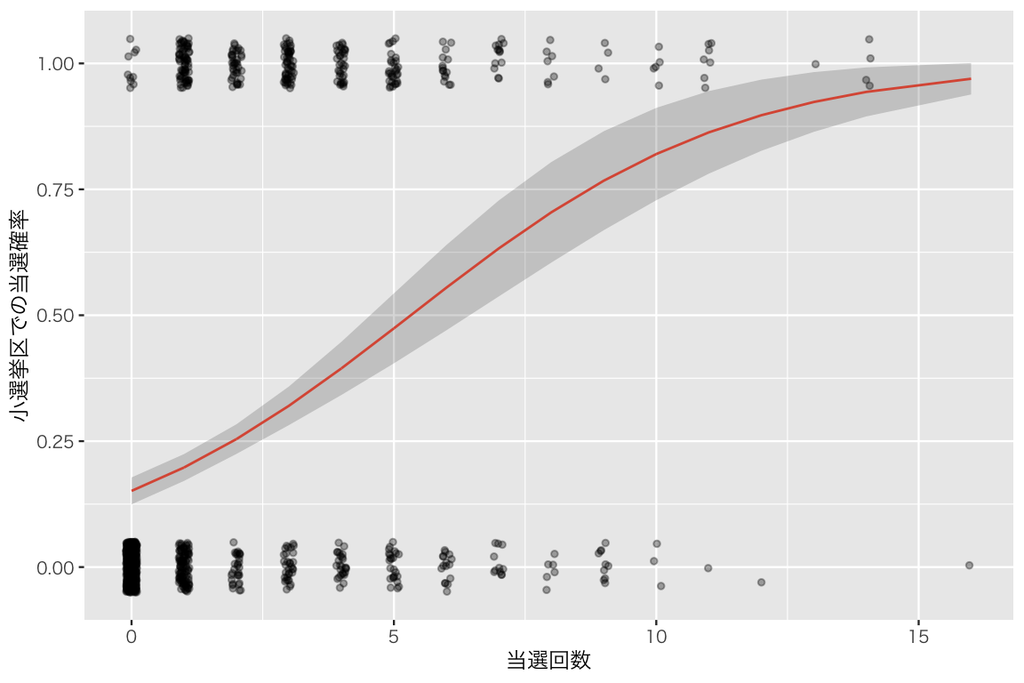

```r
p_pred2se <- p_pred2 +
  geom_ribbon(data = HR09,
              aes(ymin = fit2_lb, ymax = fit2_ub),
              alpha = 0.2)
plot(p_pred2se)
```

ロジスティック回帰の結果に信頼区間を加えることができた。

授業の内容に戻る